# Lab11_James

James Forster III

2024-03-27

```r
library(tidyverse)
```

```r
library(plotly)
library(knitr)
library(DT)
library(readr)
```

# Exercise 1

## Overview of National Grasslands LBJ

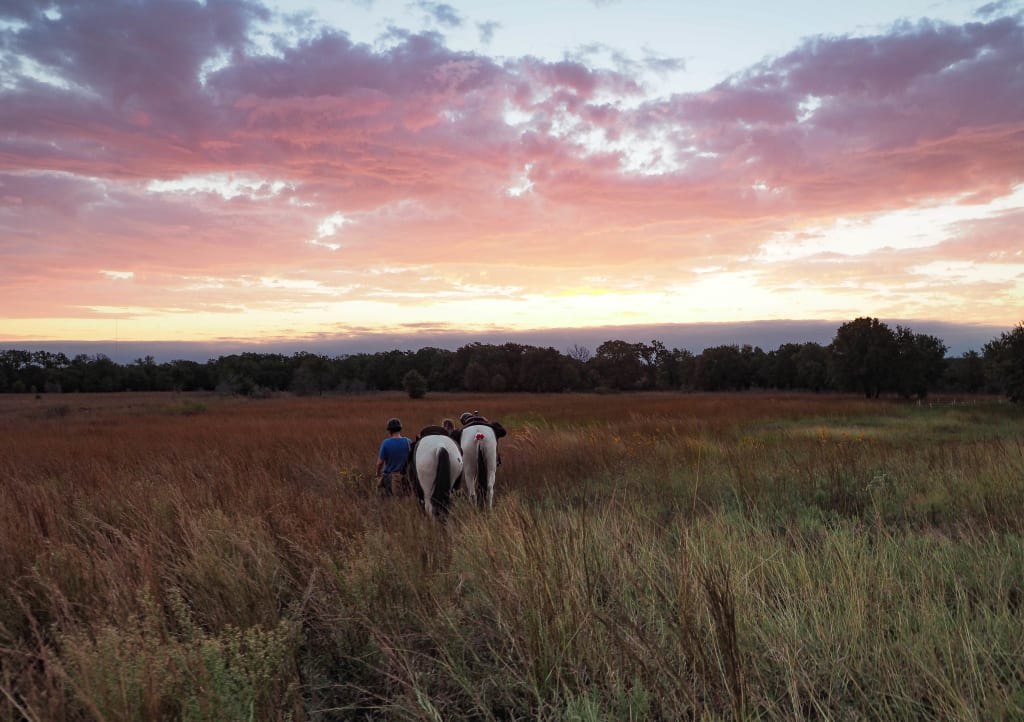

A Texas Sunset over the LBJ National Grasslands. Credits: Pam LeBlanc photo

Long through history, the lands that would become the LBJ National Grasslands were favorite hunting grounds for native tribes such as the Cherokee, Creek, Seminole, Waco, and Kickapoo (Dferriero 2021). In fact, the earliest discovered human artifacts in North America, namely remains of animals, seeds, and various others were discovered not far from this region (“Fort Worth History” n.d.; “Human History” 2023).

Ranching has always been historically associated with Texas, and Fort Worth was home to some of the largest cattle trades in the world. Ranchers would drive their cattle from throughout the Great Plains to be sold or traded at the Fort Worth stockyard (“Home Fort Worth Stockyards” n.d.).

As such, the grasslands surrounding Fort Worth became essential grazing lands along the final legs of cattle drives. The approximately 20,250 acres surrounding Black Creek Lake Northwest of Fort Worth was soon worked extensively by cattle drivers and homesteaders alike. With a steady influx of homesteaders across the great plains, land mismanagement become a major problem, eventually culminating in the dust bowl, which devastated the natural resources of the region (“Human History” 2023).

President Hoover then began researching agricultural remedies, and his successor, Franklin D. Roosevelt ended land giveaways and began federal management of certain natural lands, including these regions. With well-placed fencing, rotation, and grazing restrictions, vegetation returned to the region around mid-century (“Human History” 2023).

Today, the LBJ National Grasslands are federally managed multiple-use areas. They are protected from being developed or plowed, but still allow limited drilling for the oil and gas industry, grazing for ranching, hunting, camping, and general tourism (“National Forests and Grasslands in Texas - Districts” n.d.).

Writing credits to my group member, Jay English

# Exercise 2

## Overview of Actinobacteriota

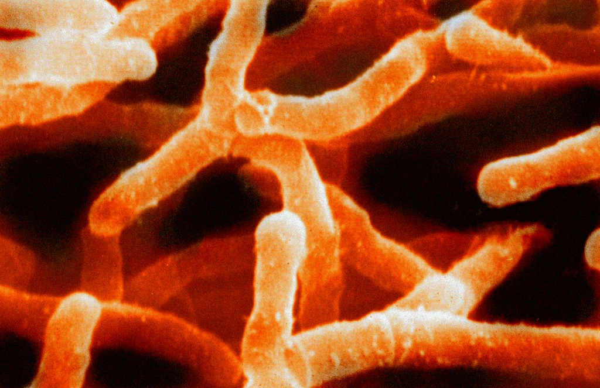

Scanning Electrom Micrograph of Actinomyes israelii

Actinobacteria are diverse, gram positive bacteria found in both aquatic and terrestrial environments(Servin et al. 2008). In soil, they are decomposers of organic matter and play a key role in the carbon cycle. This niche is likely distinct from decomposers such as fungi, as they often form symbiotic relationships with plants as nitrogen fixers(Kakoi et al. 2014).

Interestingly, for a long time Actinomycetota colonies were believed to be fungi as they form extensive mycelia. This is how they were actually named (myc being derived from the Greek “myket” for “mushroom”)(Buchanan 1917).

Certain Actinomycetota are important members of the human microbiome. In fact, the genus Bifidobacterium are the most common bacteria in the human infant microbiome(Turroni et al. 2012). In the intestines, bifidobacteria help maintain the mucosal barrier and play a key role in reduction of inflammation by reducing lipopolysacharides in the GI tract(Turroni et al. 2012).

Actinobacteria are also relevant to human disease. Some members of the genus Mycobacterium, for instance, are pathogenic and are the cause of diseases such as tuberculosis, leprosy, diptheria, vaginosis, and others(Lewin et al. 2016). Still others from the genus Steptomyces are a major source of common antibiotics used in medicine(Lima Procópio et al. 2012).

Writing credits to my group member, Jay English

```r
Project_MAGs <- read.csv("Project_MAGs.csv")
```

```r
Project_MAGs_LBJ <- Project_MAGs %>%
  filter(Site == "National Grasslands LBJ, Texas, USA")
```

# Exercise 3

## National Grasslands LBJ MAGs Overview

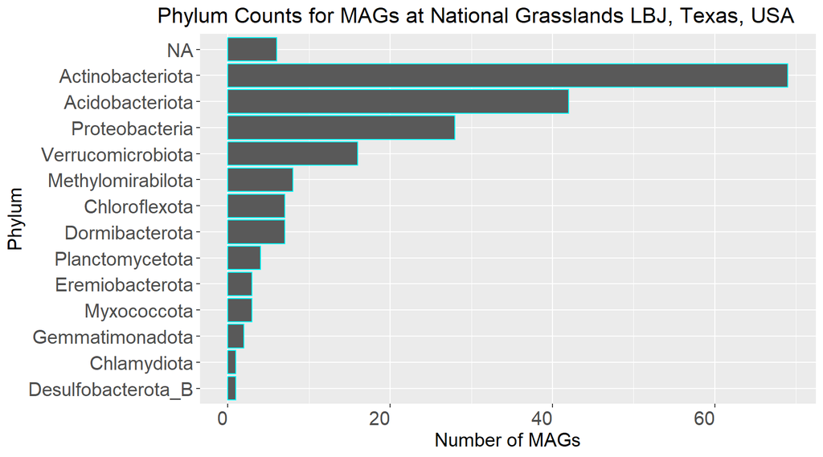

```r
Project_MAGs_LBJ %>%
ggplot(aes(x = fct_rev(fct_infreq(Phylum)))) +
    geom_bar(color = "cyan") +
    labs(title = "Phylum Counts for MAGs at National Grasslands LBJ, Texas, USA", x = "Phylum", y = "Number of MAGs") +
theme(axis.text.x = element_text(size = 15, angle = 0, hjust = 1, vjust = 1),
                        axis.text.y = element_text(size = 15),
                        text = element_text(size = 15), plot.title = element_text(size = 17, hjust = 2))+
  coord_flip()
```

Now we can highlight the classes that each phylum belongs to, for LBJ.

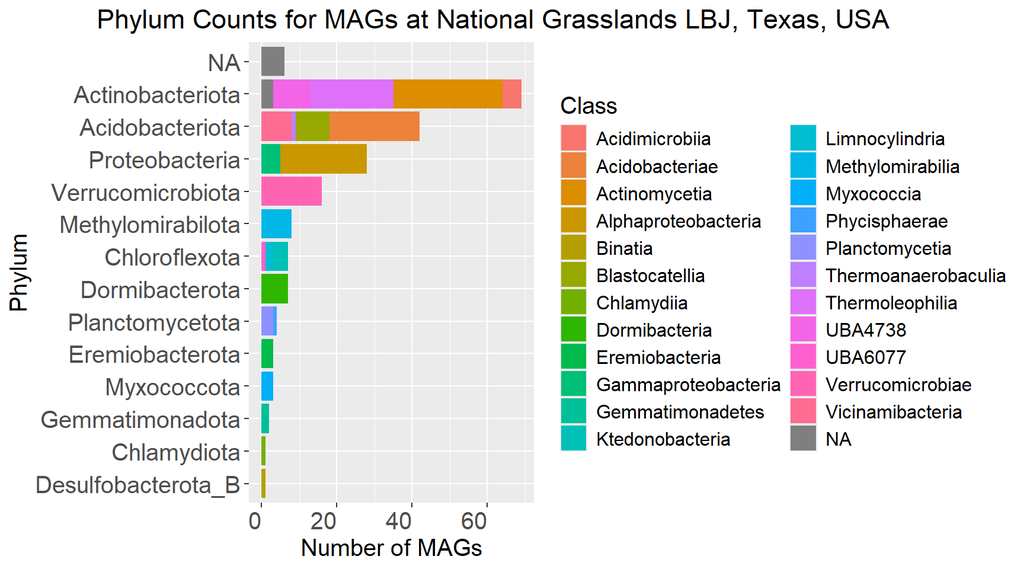

```r
Project_MAGs_LBJ %>%
ggplot(aes(x = fct_rev(fct_infreq(Phylum)), fill = Class)) +
    geom_bar() +
    labs(title = "Phylum Counts for MAGs at National Grasslands LBJ, Texas, USA", x = "Phylum", y = "Number of MAGs") +
theme(axis.text.x = element_text(size = 15, angle = 0, hjust = 1, vjust = 1),
                        axis.text.y = element_text(size = 15),
                        text = element_text(size = 15), plot.title = element_text(size = 17, hjust = .3))+
  coord_flip()
```

Clearly, our Phylum, Actinobacteriota, makes up the highest percentage of bacteria MAGs at the site! We can also assess the different classes that make up the bacterial MAGs at LBJ:

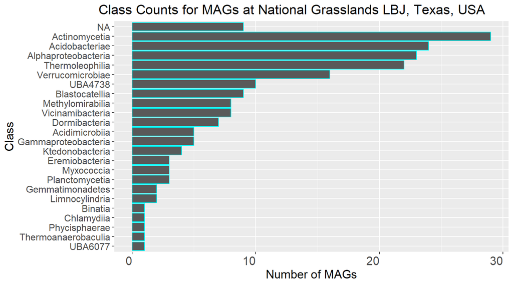

```r
Project_MAGs_LBJ %>%
ggplot(aes(x = fct_rev(fct_infreq(Class)))) +
    geom_bar(color = "cyan") +
    labs(title = "Class Counts for MAGs at National Grasslands LBJ, Texas, USA", x = "Class", y = "Number of MAGs") +
theme(axis.text.x = element_text(size = 15, angle = 0, hjust = 1, vjust = 1),
                        axis.text.y = element_text(size = 12),
                        text = element_text(size = 15), plot.title = element_text(size = 17, hjust = -2))+
  coord_flip()
```

It may also be useful to assess the genome size histogram of all the bacteria at our site:

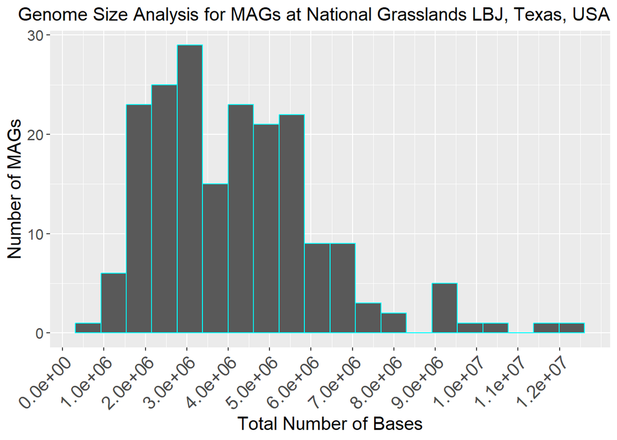

```r
Project_MAGs_LBJ %>%
ggplot(aes(x= Total.Number.of.Bases)) +
  labs(title = "Genome Size Analysis for MAGs at National Grasslands LBJ, Texas, USA", x = "Total Number of Bases", y = "Number of MAGs") +
  geom_histogram(bins = 20, color = "cyan") +
  scale_x_continuous(breaks = seq(0, max(Project_MAGs_LBJ$Total.Number.of.Bases), by = 1000000)) +
  theme(axis.text.x = element_text(size = 15, angle = 45, hjust = 1, vjust = 1),
                        axis.text.y = element_text(size = 12),
                        text = element_text(size = 15), plot.title = element_text(size = 15, hjust = 1))
```

Along with viewing the National Grasslands LBJ Mags in table mode:

```r
datatable(Project_MAGs_LBJ)
```

|  | X | Bin.ID | Site | Sample.Name | Site.ID | Subplot | Layer | Date | IMG.Genome.ID | Bin.Quality | Bin.Lineage | GTDB.Tk.Taxonomy.Lineage | Domain | Phylum | Class | Order | Family | Genus | Bin.Completeness | Bin.Contamination | Total.Number.of.Bases | X5s.rRNA | X16s.rRNA | X23s.rRNA | tRNA.Genes | Gene.Count | Scaffold.Count | Assembly.Type |
| --- | --- | --- | --- | --- | --- | --- | --- | --- | --- | --- | --- | --- | --- | --- | --- | --- | --- | --- | --- | --- | --- | --- | --- | --- | --- | --- | --- | --- |
| 1 | 1 | 3300060643_14 | National Grasslands LBJ, Texas, USA | CLBJ_001-M-20210506 | CLBJ | 1 | M | 20210506 | 3300060643 | MQ |  | Bacteria; Acidobacteriota; Blastocatellia; Pyrinomonadales; Pyrinomonadaceae; PSRF01 | Bacteria | Acidobacteriota | Blastocatellia | Pyrinomonadales | Pyrinomonadaceae | PSRF01 | 96.15 | 2.56 | 6247032 | 0 | 1 | 0 | 54 | 5373 | 39 | Individual |
| 2 | 2 | 3300060643_16 | National Grasslands LBJ, Texas, USA | CLBJ_001-M-20210506 | CLBJ | 1 | M | 20210506 | 3300060643 | MQ | Bacteria | Bacteria; Acidobacteriota; Vicinamibacteria; Vicinamibacterales; UBA2999; Gp6-AA45 | Bacteria | Acidobacteriota | Vicinamibacteria | Vicinamibacterales | UBA2999 | Gp6-AA45 | 77.5 | 5.3 | 5394623 | 0 | 0 | 0 | 32 | 5406 | 878 | Individual |
| 3 | 3 | 3300060643_18 | National Grasslands LBJ, Texas, USA | CLBJ_001-M-20210506 | CLBJ | 1 | M | 20210506 | 3300060643 | MQ | Bacteria; Actinomycetota; Actinomycetes | Bacteria; Actinobacteriota; Actinomycetia; Streptosporangiales; Streptosporangiaceae; Chersky-822 | Bacteria | Actinobacteriota | Actinomycetia | Streptosporangiales | Streptosporangiaceae | Chersky-822 | 77.15 | 1.99 | 4389455 | 0 | 0 | 0 | 35 | 4705 | 607 | Individual |
| 4 | 4 | 3300060643_2 | National Grasslands LBJ, Texas, USA | CLBJ_001-M-20210506 | CLBJ | 1 | M | 20210506 | 3300060643 | MQ | Bacteria; Actinomycetota; Actinomycetes | Bacteria; Actinobacteriota; Actinomycetia; Mycobacteriales; Jatrophihabitantaceae; JAFAWL01 | Bacteria | Actinobacteriota | Actinomycetia | Mycobacteriales | Jatrophihabitantaceae | JAFAWL01 | 58.36 | 3.74 | 3228217 | 0 | 0 | 0 | 29 | 3762 | 592 | Individual |
| 5 | 5 | 3300060643_28 | National Grasslands LBJ, Texas, USA | CLBJ_001-M-20210506 | CLBJ | 1 | M | 20210506 | 3300060643 | MQ | Bacteria; Pseudomonadota; Alphaproteobacteria; Hyphomicrobiales | Bacteria; Proteobacteria; Alphaproteobacteria; Rhizobiales; Xanthobacteraceae; VAZQ01 | Bacteria | Proteobacteria | Alphaproteobacteria | Rhizobiales | Xanthobacteraceae | VAZQ01 | 68.73 | 4.67 | 3245901 | 0 | 0 | 0 | 12 | 3446 | 474 | Individual |
| 6 | 6 | 3300060643_35 | National Grasslands LBJ, Texas, USA | CLBJ_001-M-20210506 | CLBJ | 1 | M | 20210506 | 3300060643 | MQ | Bacteria; Acidobacteriota | Bacteria; Acidobacteriota; Blastocatellia; Pyrinomonadales; Pyrinomonadaceae | Bacteria | Acidobacteriota | Blastocatellia | Pyrinomonadales | Pyrinomonadaceae |  | 50.86 | 0 | 3539077 | 1 | 0 | 1 | 26 | 3432 | 386 | Individual |
| 7 | 7 | 3300060643_5 | National Grasslands LBJ, Texas, USA | CLBJ_001-M-20210506 | CLBJ | 1 | M | 20210506 | 3300060643 | MQ | Bacteria; Chloroflexota; Ktedonobacteria; Ktedonobacterales; Dictyobacteraceae | Bacteria; Chloroflexota; Ktedonobacteria; Ktedonobacterales; Ktedonobacteraceae | Bacteria | Chloroflexota | Ktedonobacteria | Ktedonobacterales | Ktedonobacteraceae |  | 59.57 | 2.97 | 3283821 | 3 | 1 | 1 | 24 | 2969 | 270 | Individual |
| 8 | 8 | 3300060643_6 | National Grasslands LBJ, Texas, USA | CLBJ_001-M-20210506 | CLBJ | 1 | M | 20210506 | 3300060643 | MQ | Bacteria | Bacteria; Acidobacteriota; Blastocatellia; Pyrinomonadales; Pyrinomonadaceae; QHXM01 | Bacteria | Acidobacteriota | Blastocatellia | Pyrinomonadales | Pyrinomonadaceae | QHXM01 | 73.28 | 3.16 | 4908522 | 0 | 1 | 0 | 37 | 4603 | 547 | Individual |
| 9 | 682 | 3300061205_10 | National Grasslands LBJ, Texas, USA | CLBJ_040-M-20210503 | CLBJ | 40 | M | 20210503 | 3300061205 | MQ | Bacteria; Actinomycetota; Actinomycetes | Bacteria; Actinobacteriota; Actinomycetia; Mycobacteriales; Jatrophihabitantaceae; WQZC01 | Bacteria | Actinobacteriota | Actinomycetia | Mycobacteriales | Jatrophihabitantaceae | WQZC01 | 74.1 | 6.84 | 4191298 | 0 | 1 | 0 | 38 | 4819 | 658 | Individual |
| 10 | 683 | 3300061205_13 | National Grasslands LBJ, Texas, USA | CLBJ_040-M-20210503 | CLBJ | 40 | M | 20210503 | 3300061205 | MQ | Bacteria | Bacteria; Desulfobacterota_B; Binatia; UBA9968; UBA9968; DP-1 | Bacteria | Desulfobacterota_B | Binatia | UBA9968 | UBA9968 | DP-1 | 67.22 | 5.04 | 5450540 | 0 | 0 | 2 | 42 | 5828 | 520 | Individual |

[output cut: 187 more lines]

Now, lets delve in and take a closer look at our Phylum, Actinobacteriota. We can first assess its abundance at each site:

## Abundance of Actinobacteriota at NEON Sites

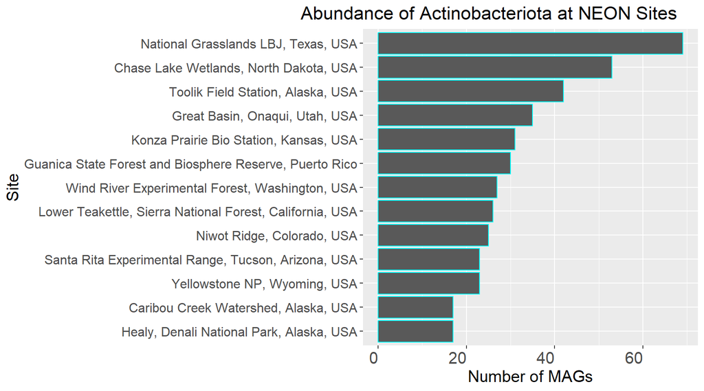

```r
Project_MAGs %>%
  filter(Phylum == "Actinobacteriota") %>%
  filter(Site != "NEON combined assembly") %>%
ggplot(aes(x = fct_rev(fct_infreq(Site)))) +
    geom_bar(color = "cyan") +
    labs(title = "Abundance of Actinobacteriota at NEON Sites", x = "Site", y = "Number of MAGs") +
theme(axis.text.x = element_text(size = 15, angle = 0, hjust = 1, vjust = 1),
                        axis.text.y = element_text(size = 12),
                        text = element_text(size = 15), plot.title = element_text(size = 17, hjust = 1.5))+
  coord_flip()
```

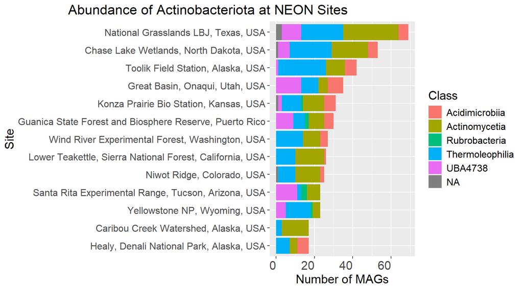

```r
Project_MAGs %>%
  filter(Phylum == "Actinobacteriota") %>%
  filter(Site != "NEON combined assembly") %>%
ggplot(aes(x = fct_rev(fct_infreq(Site)), fill = Class)) +
    geom_bar() +
    labs(title = "Abundance of Actinobacteriota at NEON Sites", x = "Site", y = "Number of MAGs") +
theme(axis.text.x = element_text(size = 15, angle = 0, hjust = 1, vjust = 1),
                        axis.text.y = element_text(size = 12),
                        text = element_text(size = 15), plot.title = element_text(size = 17, hjust = 1.5))+
  coord_flip()
```

Interestingly, actinobacteriota is found most predominantly at National Grasslands LBJ, our site! We can also take a look and see some of the lower level taxonomic breakdown of these actinobacteriota:

### Taxonomic Breakdown of Actinobacteriota at Sites

#### Class

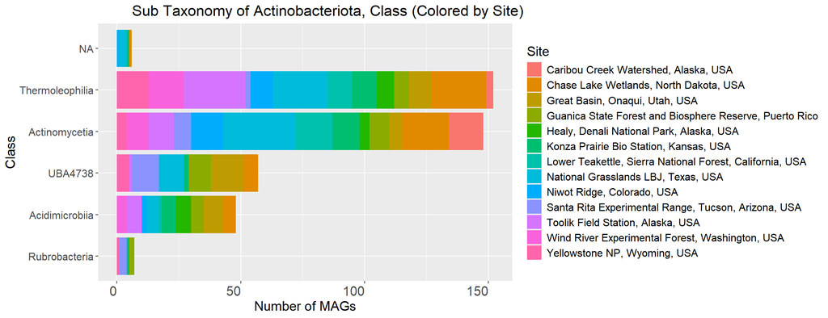

```r
Project_MAGs %>%
  filter(Phylum == "Actinobacteriota") %>%
  filter(Site != "NEON combined assembly") %>%
ggplot(aes(x = fct_rev(fct_infreq(Class)), fill = Site)) +
    geom_bar() +
    labs(title = "Sub Taxonomy of Actinobacteriota, Class (Colored by Site)", x = "Class", y = "Number of MAGs") +
theme(axis.text.x = element_text(size = 15, angle = 0, hjust = 1, vjust = 1),
                        axis.text.y = element_text(size = 12),
                        text = element_text(size = 15), plot.title = element_text(size = 17, hjust = 1.5))+
  coord_flip()
```

#### Order

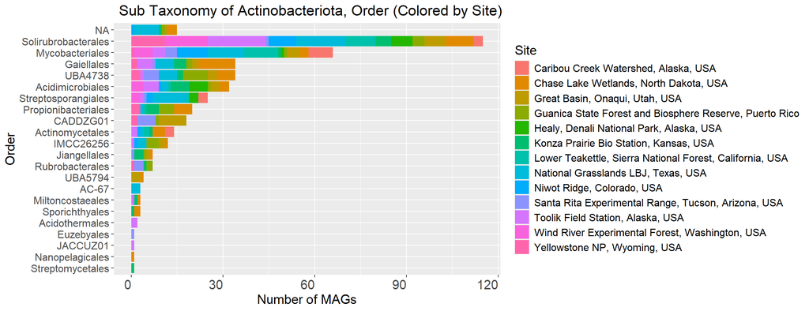

```r
Project_MAGs %>%
  filter(Phylum == "Actinobacteriota") %>%
  filter(Site != "NEON combined assembly") %>%
ggplot(aes(x = fct_rev(fct_infreq(Order)), fill = Site)) +
    geom_bar() +
    labs(title = "Sub Taxonomy of Actinobacteriota, Order (Colored by Site)", x = "Order", y = "Number of MAGs") +
theme(axis.text.x = element_text(size = 15, angle = 0, hjust = 1, vjust = 1),
                        axis.text.y = element_text(size = 12),
                        text = element_text(size = 15), plot.title = element_text(size = 17, hjust = 1.5))+
  coord_flip()
```

#### Family

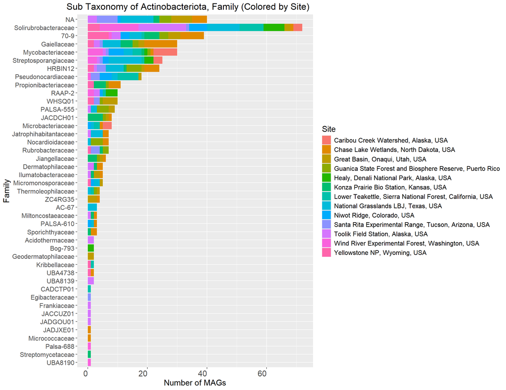

```r
Project_MAGs %>%
  filter(Phylum == "Actinobacteriota") %>%
  filter(Site != "NEON combined assembly") %>%
ggplot(aes(x = fct_rev(fct_infreq(Family)), fill = Site)) +
    geom_bar() +
    labs(title = "Sub Taxonomy of Actinobacteriota, Family (Colored by Site)", x = "Family", y = "Number of MAGs") +
theme(axis.text.x = element_text(size = 15, angle = 0, hjust = 1, vjust = 1),
                        axis.text.y = element_text(size = 12),
                        text = element_text(size = 15), plot.title = element_text(size = 17, hjust = 1.5))+
  coord_flip()
```

This gives us alot of useful information. However, going further down the taxonomy might give us too much information! So we will stop at family. Although if we wanted, we could determine even the species of each actinobacteriota, colored by site.

# Exercise 4

```r
Site_IMG <- read_tsv("data/exported_img_data.tsv")  #Loading TSV of IMG data for LBJ site
Site_IMG_annotated <- Site_IMG %>%
  filter(grepl("re-annotation", `Genome Name / Sample Name`))
datatable(Site_IMG_annotated)
```

|  | taxon_oid | Domain | Sequencing Status | Study Name | Genome Name / Sample Name | Sequencing Center | IMG Genome ID | GOLD Study ID | Ecosystem | Ecosystem Category | Ecosystem Subtype | Ecosystem Type | Specific Ecosystem | Latitude | Longitude | Genome Size * assembled | Gene Count * assembled |
| --- | --- | --- | --- | --- | --- | --- | --- | --- | --- | --- | --- | --- | --- | --- | --- | --- | --- |
| 1 | 3300069301 | *Microbiome | Permanent Draft | Terrestrial soil microbial communities from various NEON sites located in USA and Puerto Rico | Terrestrial soil microbial communities from Caribou Creek Watershed, Alaska, USA - BONA_001-O-20210708-comp-1 re-annotation | DOE Joint Genome Institute (JGI) | 3300069301 | Gs0161344 | Environmental | Terrestrial | Boreal forest/Taiga | Soil | Unclassified | 65.174447 | -147.478155 | 3440548901 | 7717678 |
| 2 | 3300069227 | *Microbiome | Permanent Draft | Terrestrial soil microbial communities from various NEON sites located in USA and Puerto Rico | Terrestrial soil microbial communities from Great Basin, Onaqui, Utah, USA - ONAQ_008-M-20210524-comp-1 re-annotation | DOE Joint Genome Institute (JGI) | 3300069227 | Gs0161344 | Environmental | Terrestrial | Shrubland | Soil | Unclassified | 40.15854 | -112.521574 | 1900961871 | 4951528 |
| 3 | 3300069247 | *Microbiome | Permanent Draft | Terrestrial soil microbial communities from various NEON sites located in USA and Puerto Rico | Terrestrial soil microbial communities from Toolik Field Station, Alaska, USA - TOOL_002-O-20210804-comp-1 re-annotation | DOE Joint Genome Institute (JGI) | 3300069247 | Gs0161344 | Environmental | Terrestrial | Tundra | Soil | Unclassified | 68.627943 | -149.347229 | 2203447209 | 4867161 |
| 4 | 3300069277 | *Microbiome | Permanent Draft | Terrestrial soil microbial communities from various NEON sites located in USA and Puerto Rico | Terrestrial soil microbial communities from Niwot Ridge, Colorado, USA - NIWO_001-O-20210728-comp-1 re-annotation | DOE Joint Genome Institute (JGI) | 3300069277 | Gs0161344 | Environmental | Terrestrial | Temperate forest | Soil | Unclassified | 40.042345 | -105.558975 | 2360663848 | 5740347 |
| 5 | 3300069215 | *Microbiome | Permanent Draft | Terrestrial soil microbial communities from various NEON sites located in USA and Puerto Rico | Terrestrial soil microbial communities from National Grasslands LBJ, Texas, USA - CLBJ_006-M-20210506-comp-1 re-annotation | DOE Joint Genome Institute (JGI) | 3300069215 | Gs0161344 | Environmental | Terrestrial | Grasslands | Soil | Unclassified | 33.39823 | -97.56673 | 3630159317 | 8549366 |
| 6 | 3300069282 | *Microbiome | Permanent Draft | Terrestrial soil microbial communities from various NEON sites located in USA and Puerto Rico | Terrestrial soil microbial communities from Santa Rita Experimental Range, Tucson, Arizona, USA - SRER_004-M-20210809-comp-1 re-annotation | DOE Joint Genome Institute (JGI) | 3300069282 | Gs0161344 | Environmental | Terrestrial | Desert | Soil | Unclassified | 31.906778 | -110.815262 | 918269569 | 2247348 |
| 7 | 3300069208 | *Microbiome | Permanent Draft | Terrestrial soil microbial communities from various NEON sites located in USA and Puerto Rico | Terrestrial soil microbial communities from Chase Lake Wetlands, North Dakota, USA - WOOD_043-M-20210712-comp-1 re-annotation | DOE Joint Genome Institute (JGI) | 3300069208 | Gs0161344 | Environmental | Terrestrial | Wetlands | Soil | Unclassified | 47.131002 | -99.242763 | 2802353118 | 6391054 |
| 8 | 3300069292 | *Microbiome | Permanent Draft | Terrestrial soil microbial communities from various NEON sites located in USA and Puerto Rico | Terrestrial soil microbial communities from Healy, Denali National Park, Alaska, USA - HEAL_048-O-20210622-comp-1 re-annotation | DOE Joint Genome Institute (JGI) | 3300069292 | Gs0161344 | Environmental | Terrestrial | Boreal forest/Taiga | Soil | Unclassified | 63.875088 | -149.210438 | 2765718207 | 5958648 |
| 9 | 3300069262 | *Microbiome | Permanent Draft | Terrestrial soil microbial communities from various NEON sites located in USA and Puerto Rico | Terrestrial soil microbial communities from Chase Lake Wetlands, North Dakota, USA - WOOD_001-M-20210714-comp-1 re-annotation | DOE Joint Genome Institute (JGI) | 3300069262 | Gs0161344 | Environmental | Terrestrial | Wetlands | Soil | Unclassified | 47.128258 | -99.257768 | 2581360018 | 6218587 |
| 10 | 3300069268 | *Microbiome | Permanent Draft | Terrestrial soil microbial communities from various NEON sites located in USA and Puerto Rico | Terrestrial soil microbial communities from Yellowstone NP, Wyoming, USA - YELL_046-M-20210705-comp-1 re-annotation | DOE Joint Genome Institute (JGI) | 3300069268 | Gs0161344 | Environmental | Terrestrial | Temperate forest | Soil | Unclassified | 44.952363 | -110.541582 | 1874275737 | 4830121 |

[output cut: 75 more lines]

# References

Association, Texas State Historical. n.d. “Comanche Indians.” *Texas State Historical Association*. Accessed April 2, 2024. https://www.tshaonline.org/handbook/entries/comanche-indians.

Buchanan, R. E. 1917. “Studies in the Nomenclature and Classification of the Bacteria.” *Journal of Bacteriology* 2 (2): 155–64. https://www.ncbi.nlm.nih.gov/pmc/articles/PMC378699/.

Dferriero. 2021. “The Importance of Acknowledging Our History: The National Archives and Federal Records Center in Fort Worth, Texas.” *This Is the Retired Blog of the 10th Archivist of the United States David S. Ferriero. Comments Are Closed.* https://aotus.blogs.archives.gov/2021/08/13/the-importance-of-acknowledging-our-history-the-national-archives-and-federal-records-center-in-fort-worth-texas/.

“Fort Worth History.” n.d. Accessed April 2, 2024. https://www.fortworthtexas.gov/about/history.

“Home Fort Worth Stockyards.” n.d. Accessed April 2, 2024. https://www.fortworthstockyards.org/.

“Human History.” 2023. *LBJ Grasslands Project*. https://lbjgproject.org/human-history/.

Kakoi, Kentaro, Masatoshi Yamaura, Toshihito Kamiharai, Daiki Tamari, Mikiko Abe, Toshiki Uchiumi, and Ken-Ichi Kucho. 2014. “Isolation of Mutants of the Nitrogen-Fixing Actinomycete Frankia.” *Microbes and Environments* 29 (1): 31–37. https://doi.org/10.1264/jsme2.ME13126.

Lewin, Gina R., Camila Carlos, Marc G. Chevrette, Heidi A. Horn, Bradon R. McDonald, Robert J. Stankey, Brian G. Fox, and Cameron R. Currie. 2016. “Evolution and Ecology of Actinobacteria and Their Bioenergy Applications.” *Annual Review of Microbiology* 70 (September): 235–54. https://doi.org/10.1146/annurev-micro-102215-095748.

Lima Procópio, Rudi Emerson de, Ingrid Reis da Silva, Mayra Kassawara Martins, João Lúcio de Azevedo, and Janete Magali de Araújo. 2012. “Antibiotics Produced by *Streptomyces*.” *The Brazilian Journal of Infectious Diseases* 16 (5): 466–71. https://doi.org/10.1016/j.bjid.2012.08.014.

“National Forests and Grasslands in Texas - Districts.” n.d. Accessed April 2, 2024. https://www.fs.usda.gov/detail/texas/about-forest/districts/?cid=fswdev3_008440.

“Native American Relations in Texas Exhibit - Currently Being Refreshed. Please Check Back Later. TSLAC.” n.d. Accessed April 2, 2024. https://www.tsl.texas.gov/exhibits/nativeamericanrelations.

Servin, Jacqueline A., Craig W. Herbold, Ryan G. Skophammer, and James A. Lake. 2008. “Evidence Excluding the Root of the Tree of Life from the Actinobacteria.” *Molecular Biology and Evolution* 25 (1): 1–4. https://doi.org/10.1093/molbev/msm249.

Turroni, Francesca, Clelia Peano, Daniel A. Pass, Elena Foroni, Marco Severgnini, Marcus J. Claesson, Colm Kerr, et al. 2012. “Diversity of Bifidobacteria Within the Infant Gut Microbiota.” *PLOS ONE* 7 (5): e36957. https://doi.org/10.1371/journal.pone.0036957.